# Medical Appointment No Shows

[Kaggle Dataset](https://www.kaggle.com/joniarroba/noshowappointments)

## Introduction

In this project we'll be analysing data associated with the **medical appointments in Brazil** and the focus is on question whether or not patients show up for their appointments. Also, we'll be interested in finding the factors that are important for us to know in order to predict if a patient will show up for their scheduled appointment.

### Data Dictionary

```
1. PatientId: Identification of a patient
2. AppointmentID: Identification of each appointment
3. Gender: Male or Female . Female is the greater proportion, woman takes way more care of they health in comparison to man.
4. AppointmentDay: The day of the actual appointment, when they have to visit the doctor.
5. ScheduledDay: The day someone called or registered the appointment, this is before appointment of course.
6. Age: How old is the patient.
7. Neighbourhood: Where the appointment takes place.
8. Scholarship: Ture of False . Observation, this is a broad topic, consider reading this article https://en.wikipedia.org/wiki/Bolsa_Fam%C3%ADlia
9. Hipertension: True or False
10. Diabetes: True or False
11. Alcoholism: True or False
12. Handcap: True or False
13. SMS_received: 1 or more messages sent to the patient.
14. No-show: True or False. It says ‘No’ if the patient showed up to their appointment, and ‘Yes’ if they did not show up.
```

```python
# Import libraries
import numpy as np
import pandas as pd
import matplotlib.pyplot as plt
import seaborn as sns
```

```python
# Load the dataset & parse the date-time columns to datetime data types
df = pd.read_csv('KaggleV2-May-2016.csv', parse_dates=['ScheduledDay', 'AppointmentDay'])
```

```python
# Read first few rows
df.head()
```

|  | PatientId | AppointmentID | Gender | ScheduledDay | AppointmentDay | Age | Neighbourhood | Scholarship | Hipertension | Diabetes | Alcoholism | Handcap | SMS_received | No-show |
| --- | --- | --- | --- | --- | --- | --- | --- | --- | --- | --- | --- | --- | --- | --- |
| 0 | 2.987250e+13 | 5642903 | F | 2016-04-29 18:38:08+00:00 | 2016-04-29 00:00:00+00:00 | 62 | JARDIM DA PENHA | 0 | 1 | 0 | 0 | 0 | 0 | No |
| 1 | 5.589978e+14 | 5642503 | M | 2016-04-29 16:08:27+00:00 | 2016-04-29 00:00:00+00:00 | 56 | JARDIM DA PENHA | 0 | 0 | 0 | 0 | 0 | 0 | No |
| 2 | 4.262962e+12 | 5642549 | F | 2016-04-29 16:19:04+00:00 | 2016-04-29 00:00:00+00:00 | 62 | MATA DA PRAIA | 0 | 0 | 0 | 0 | 0 | 0 | No |
| 3 | 8.679512e+11 | 5642828 | F | 2016-04-29 17:29:31+00:00 | 2016-04-29 00:00:00+00:00 | 8 | PONTAL DE CAMBURI | 0 | 0 | 0 | 0 | 0 | 0 | No |
| 4 | 8.841186e+12 | 5642494 | F | 2016-04-29 16:07:23+00:00 | 2016-04-29 00:00:00+00:00 | 56 | JARDIM DA PENHA | 0 | 1 | 1 | 0 | 0 | 0 | No |

```python
# Shape
print("There are {} rows and {} columns in the No-Show Appointment dataset.".format(df.shape[0],df.shape[1]))
```

```
There are 110527 rows and 14 columns in the No-Show Appointment dataset.
```

```python
# Check Null values
df.isnull().sum().sort_values(ascending=False)
```

```
No-show           0
SMS_received      0
Handcap           0
Alcoholism        0
Diabetes          0
Hipertension      0
Scholarship       0
Neighbourhood     0
Age               0
AppointmentDay    0
ScheduledDay      0
Gender            0
AppointmentID     0
PatientId         0
dtype: int64
```

```python
# Check Duplicates
df.duplicated().sum()
```

```
0
```

```python
# Statistical Summary of Numerical Columns
df.describe()
```

|  | PatientId | AppointmentID | Age | Scholarship | Hipertension | Diabetes | Alcoholism | Handcap | SMS_received |
| --- | --- | --- | --- | --- | --- | --- | --- | --- | --- |
| count | 1.105270e+05 | 1.105270e+05 | 110527.000000 | 110527.000000 | 110527.000000 | 110527.000000 | 110527.000000 | 110527.000000 | 110527.000000 |
| mean | 1.474963e+14 | 5.675305e+06 | 37.088874 | 0.098266 | 0.197246 | 0.071865 | 0.030400 | 0.022248 | 0.321026 |
| std | 2.560949e+14 | 7.129575e+04 | 23.110205 | 0.297675 | 0.397921 | 0.258265 | 0.171686 | 0.161543 | 0.466873 |
| min | 3.921784e+04 | 5.030230e+06 | -1.000000 | 0.000000 | 0.000000 | 0.000000 | 0.000000 | 0.000000 | 0.000000 |
| 25% | 4.172614e+12 | 5.640286e+06 | 18.000000 | 0.000000 | 0.000000 | 0.000000 | 0.000000 | 0.000000 | 0.000000 |
| 50% | 3.173184e+13 | 5.680573e+06 | 37.000000 | 0.000000 | 0.000000 | 0.000000 | 0.000000 | 0.000000 | 0.000000 |
| 75% | 9.439172e+13 | 5.725524e+06 | 55.000000 | 0.000000 | 0.000000 | 0.000000 | 0.000000 | 0.000000 | 1.000000 |
| max | 9.999816e+14 | 5.790484e+06 | 115.000000 | 1.000000 | 1.000000 | 1.000000 | 1.000000 | 4.000000 | 1.000000 |

```python
# Statistical Summary of Categorical Columns
df.describe(include='O')
```

|  | Gender | Neighbourhood | No-show |
| --- | --- | --- | --- |
| count | 110527 | 110527 | 110527 |
| unique | 2 | 81 | 2 |
| top | F | JARDIM CAMBURI | No |
| freq | 71840 | 7717 | 88208 |

```python
# SMS received vs not received
sms_rec = round((df.SMS_received.value_counts()[1]/df.SMS_received.value_counts()[0])*100, 2)
print("{}% had received the appointment SMS.".format(sms_rec))
```

```
47.28% had received the appointment SMS.
```

```python
df.info()
```

```
<class 'pandas.core.frame.DataFrame'>
RangeIndex: 110527 entries, 0 to 110526
Data columns (total 14 columns):
PatientId         110527 non-null float64
AppointmentID     110527 non-null int64
Gender            110527 non-null object
ScheduledDay      110527 non-null datetime64[ns, UTC]
AppointmentDay    110527 non-null datetime64[ns, UTC]
Age               110527 non-null int64
Neighbourhood     110527 non-null object
Scholarship       110527 non-null int64
Hipertension      110527 non-null int64
Diabetes          110527 non-null int64
Alcoholism        110527 non-null int64
Handcap           110527 non-null int64
SMS_received      110527 non-null int64
No-show           110527 non-null object
dtypes: datetime64[ns, UTC](2), float64(1), int64(8), object(3)
memory usage: 11.8+ MB
```

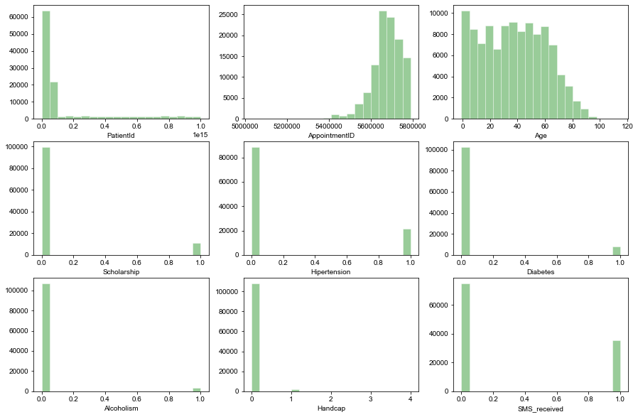

```python
# Find numerical columns
num_cols = [x for x in df.dtypes.index if (df.dtypes[x]==float) or (df.dtypes[x]== int)]
# Create subplots
fig, axes = plt.subplots(nrows=3, ncols=3, figsize=(15,10))
# Create Univariate plots for all numerical columns
for i, ax in zip(range(9), axes.flat):
    sns.set_style('darkgrid')
    sns.distplot(df[num_cols[i]], bins=20, kde=False, ax=ax, color='g')
plt.show()
```

#### Observations:

```
1. There are a total of 110527 rows and 14 columns in the dataset. The dataset do not contain any missing values or duplicate records.

2. The descriptive statistics and the histogram shows that the age column has a minimum value of -1 which is impossible as age cannot be negative and a maximum of 115 years which denotes the outlier in the age column. Also, the age showed as 0 for a considerable amount of people who had taken the appointment. We will not remove the age having the value as 0 as these might be new born babies having their appointments with the doctor.

3. From the histogram of Handcap, the bandwith shows the value from 0 to 4 while the data dictionary tells that handcap can only be 0 or 1.
```

**At the discussion forum, it is explained by the data creator that the handicap values denotes the number of disabilites the patient have.**

[output not shown]